# CRISP-DM_process

```python
import sklearn
print('The scikit-learn version is {}.'.format(sklearn.__version__))
```

```
The scikit-learn version is 1.2.1.
```

```python
import os
os.environ['PATH'] = f"{os.environ['PATH']}:/root/.local/bin"
```

```python
!python -m pip install --upgrade scikit-learn
import sklearn
print('The scikit-learn version is {}.'.format(sklearn.__version__))
```

```
The scikit-learn version is 1.2.1.
```

[output not shown]

```python
# Now you can import and use OneHotEncoder
from sklearn.preprocessing import OneHotEncoder
# your code goes here
```

```python
# Similarly, should you need any other package, they can install it as:
!python -m pip install 'tensorflow-tensorboard<0.2.0,>=0.1.0'
```

```
Das System kann die angegebene Datei nicht finden.
```

### Question to answer

I choose the following questions to answer in the fourth assignment of data scientist training

- What are the three most offered engine boats in Germany and what specifications do these boats have?
- What sells best at the Bodensee (lake of constance)?
- Where are these boats cheapest to buy in Germany?

```python
# import libraries here; add more as necessary
import numpy as np
import pandas as pd
import matplotlib.pyplot as plt
import seaborn as sns
import sklearn
from sklearn.preprocessing import OneHotEncoder
import re
import ast
from sklearn.preprocessing import StandardScaler
from sklearn.cluster import KMeans
import pickle
import csv

# magic word for producing visualizations in notebook
%matplotlib inline

'''
Import note: The classroom currently uses sklearn version 0.19.
If you need to use an imputer, it is available in sklearn.preprocessing.Imputer,
instead of sklearn.impute as in newer versions of sklearn.
'''
pd.options.display.max_rows = None
pd.options.display.max_columns = None
```

### Prepare data

- Gather necessary data to answer your questions
- Handle categorical and missing data
- Provide insight into the methods you chose and why you chose them

#### Information about the used dataset

For this task a data set is taken into account of engine boat sell offers in Europe + Swizerland and some other countries from a marketing team. The data set includes 10 categories: Price, Boat Type, Manufacturer, Type, Year Built, Length, Width, Material, Location and Number of views last 7 days. This is a good starting point for investigating the most favoured boats on the lake of constance ant where to buy them the cheapest in Europe.The Source of data is: https://www.kaggle.com/datasets/karthikbhandary2/boat-sales?resource=download

The dataset does not take sailing yachts into account.

```python
# Load in the boat data.
boat_data = pd.read_csv('boat_data.csv', sep=',',encoding='utf-8')
```

```python
boat_data.head(25)
```

|  | Price | Boat Type | Manufacturer | Type | Year Built | Length | Width | Material | Location | Number of views last 7 days |
| --- | --- | --- | --- | --- | --- | --- | --- | --- | --- | --- |
| 0 | CHF 3337 | Motor Yacht | Rigiflex power boats | new boat from stock | 2017 | 4.00 | 1.90 | NaN | 0 Switzerland » Lake Geneva ... | 226 |
| 1 | EUR 3490 | Center console boat | Terhi power boats | new boat from stock | 2020 | 4.00 | 1.50 | Thermoplastic | 0 Switzerland » Lake Geneva ... | 75 |
| 2 | CHF 3770 | Sport Boat | Marine power boats | new boat from stock | 0 | 3.69 | 1.42 | Aluminium | 0 Switzerland » Lake Geneva ... | 124 |
| 3 | DKK 25900 | Sport Boat | Pioner power boats | new boat from stock | 2020 | 3.00 | 1.00 | NaN | 0 Switzerland » Lake Geneva ... | 64 |
| 4 | EUR 3399 | Fishing Boat | Linder power boats | new boat from stock | 2019 | 3.55 | 1.46 | Aluminium | 0 Switzerland » Lake Geneva ... | 58 |
| 5 | CHF 3650 | Sport Boat | Linder power boats | new boat from stock | 0 | 4.03 | 1.56 | Aluminium | 0 Switzerland » Lake Geneva ... | 132 |
| 6 | CHF 3600 | Catamaran | NaN | Used boat,Unleaded | 1999 | 6.20 | 2.38 | Aluminium | 0 Switzerland » Lake Geneva ... | 474 |
| 7 | DKK 24800 | Sport Boat | NaN | Used boat | 0 | 3.00 | NaN | NaN | 0 Switzerland » Lake Geneva ... | 134 |
| 8 | EUR 3333 | Fishing Boat | Crescent power boats | new boat from stock | 2019 | 3.64 | 1.37 | NaN | 0 Switzerland » Lake Geneva ... | 45 |
| 9 | EUR 3300 | Pontoon Boat | Whaly power boats | new boat from stock | 2018 | 4.35 | 1.73 | NaN | 0 Switzerland » Lake Geneva ... | 180 |
| 10 | CHF 3500 | Fishing Boat | Terhi power boats | Used boat,Electric | 1987 | 4.35 | 1.75 | GRP | 0 Switzerland » Lake Geneva ... | 239 |
| 11 | CHF 3480 | Fishing Boat | Marine power boats | new boat from stock | 0 | 4.13 | 1.41 | Aluminium | 0 Switzerland » Lake Geneva ... | 145 |
| 12 | EUR 3500 | Sport Boat | GS Nautica power boats | Used boat | 2004 | 4.70 | 2.00 | GRP | 0 Switzerland » Lake Geneva ... | 69 |
| 13 | CHF 4600 | Runabout | Kimple power boats | new boat from stock | 2020 | 4.40 | 1.65 | Aluminium | 0 Switzerland » Lake Geneva ... | 113 |
| 14 | CHF 4500 | Fishing Boat | Italmarine power boats | Used boat,Unleaded | 1997 | 3.72 | 1.33 | Aluminium | 0 Switzerland » Lake Geneva ... | 413 |
| 15 | CHF 4400 | Deck Boat | Buster power boats | new boat from stock,Unleaded | 0 | 3.88 | 1.49 | Aluminium | 0 Switzerland » Lake Geneva ... | 263 |
| 16 | CHF 4380 | Sport Boat | Linder power boats | new boat from stock | 0 | 4.31 | 1.64 | Aluminium | 0 Switzerland » Lake Geneva ... | 462 |
| 17 | DKK 30000 | Sport Boat | NaN | Used boat | 1985 | 4.00 | 1.00 | NaN | 0 Switzerland » Lake Geneva ... | 124 |
| 18 | EUR 4000 | Pilothouse | Bénéteau power boats | Used boat,Diesel | 1981 | 8.00 | 2.84 | PVC | 0 Switzerland » Lake Geneva ... | 265 |
| 19 | EUR 4000 | Cabin Boat | NaN | Used boat,Unleaded | 2011 | 6.37 | 2.31 | GRP | 0 Switzerland » Lake Geneva ... | 330 |
| 20 | EUR 3999 | Fishing Boat | Linder power boats | new boat from stock | 2019 | 3.55 | 1.46 | Aluminium | 0 Switzerland » Lake Geneva ... | 69 |
| 21 | CHF 4267 | Fishing Boat | Quicksilver (Brunswick Marine) power boats | new boat from stock,Unleaded | 0 | 3.78 | 1.71 | GRP | 0 Switzerland » Lake Geneva ... | 198 |
| 22 | EUR 3930 | Sport Boat | Linder power boats | new boat from stock,Unleaded | 2020 | 4.31 | 1.64 | Aluminium | 0 Switzerland » Lake Geneva ... | 90 |
| 23 | EUR 3900 | Sport Boat | Kammin power boats | Used boat,Unleaded | 1979 | 5.60 | 2.10 | GRP | 0 Switzerland » Lake Geneva ... | 98 |
| 24 | EUR 3900 | Cabin Boat | NaN | Used boat | 1985 | 6.53 | 2.47 | NaN | 0 Switzerland » Lake Geneva ... | 383 |

```python
# Data preparation
# Investigation how the "Bodensee, Lake of Constance is spelled in the data set"

unique_locations = boat_data['Location'].unique().tolist()
print(len(unique_locations))
#print(unique_locations)

#Lake Constance
#Konstanz
#Constance
#Bodensee

# Replace multiple spelling of the Lake Constance by "Bodensee"
boat_data_cleaned = boat_data.copy()

# List of names to replace by "Bodensee"
terms_to_replace = ['Lake Constance', 'Konstanz', 'Constance', 'Bodensee', 'bodensee','lake constance', 'konstanz', 'constance',]

# Define function to replace listed values by a new one
def replace_location(location):
    if isinstance(location, str):  # Is string?
        for term in terms_to_replace:
            if term in location:
                return 'Bodensee'
    return location

#Define function to shorten the locations to countries and copy the remaining location into a new column location area
def split_location(location):
    if isinstance(location, str):  # Is string?
        parts = location.split(' ', 1)  # Split at the first whitespace
        if len(parts) > 1:
            return pd.Series([parts[0], parts[1]])
        else:
            return pd.Series([parts[0], np.nan])
    return pd.Series([location, np.nan])

#Recalculate all boat prices into €

# Exchange rate table
exchange_rates = {
    'CHF': 0.92,  # 1 CHF = 0.92 EUR
    'DKK': 0.13,  # 1 DKK = 0.13 EUR
    'EUR': 1.0    # EUR stays unchanged
}

# function for calculation
def convert_to_euro(price):
    if isinstance(price, str):
        currency, amount = price.split(' ', 1)
        amount = float(amount.replace(',', '').replace('.', ''))
        if currency in exchange_rates:
            return amount * exchange_rates[currency]
    return np.nan

# Remove nan and 0 values
def remove_zero_or_nan_rows(df):
    cleaned_df = df.replace(0, np.nan)  # Entfernt Zeilen mit 0 Einträgen
    cleaned_df = df.dropna()  # Entfernt Zeilen mit NaN in 'Year Built'

    return cleaned_df


# Apply functions

#Replace by Bodensee
boat_data_cleaned['Location'] = boat_data_cleaned['Location'].apply(replace_location)
unique_locations_cleaned = boat_data_cleaned['Location'].unique().tolist()
print(len(unique_locations_cleaned))

# Umrechnung der Preise
boat_data_cleaned['Price (EUR)'] = boat_data_cleaned['Price'].apply(convert_to_euro)
boat_data_cleaned.drop(columns=['Price'], inplace=True)

# Remove 0 and none rows
#boat_data_cleaned = remove_zero_or_nan_rows(boat_data_cleaned)
# --> It's defined but not used since then important data is missing in the data frame. Instead nan values are get a special treatment in the analysis part.

#Split location cell
boat_data_cleaned_countries_splitted = boat_data_cleaned.copy()
boat_data_cleaned_countries_splitted[['Location', 'Location Area']] = boat_data_cleaned_countries_splitted['Location'].apply(split_location)

#store to csv
boat_data_cleaned_countries_splitted.to_csv('boat_data_cleaned_countries_splitted.csv', index=False)

#Plot the distribution of boat sells offers by location
location_distribution = boat_data_cleaned_countries_splitted['Location'].value_counts()
print(location_distribution.head(40))
```

```
2996
2901
Germany        1798
Italy          1793
France         1229
Netherlands    1056
Switzerland     954
Croatia         811
Spain           702
Bodensee        290
United          238
Denmark         172
Portugal        135
Greece           83
Austria          82
Malta            72
Turkey           64
Belgium          62
Poland           41
Slovenia         39
Finland          35
Montenegro       22
Sweden           13
Monaco           10
Slovak            9
Lake              7
Russian           7
Estonia           6
Lithuania         5
Czech             5
Cyprus            5
Donau             4
Hungary           4
Bulgaria          3
Thailand          3
Latvia            3
Lago              3
Martinique        2
Norway            2
Ukraine           2
Ostsee            2
Australia         2
Name: Location, dtype: int64
```

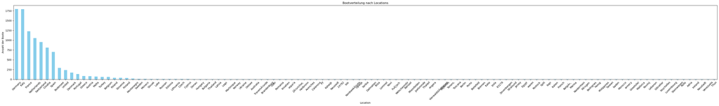

```python
# Bar Chart plotten
plt.figure(figsize=(40, 6))
location_distribution.plot(kind='bar', color='skyblue')
plt.title('Bootverteilung nach Locations')
plt.xlabel('Location')
plt.ylabel('Anzahl der Boote')
plt.xticks(rotation=45)
plt.tight_layout()
plt.show()
```

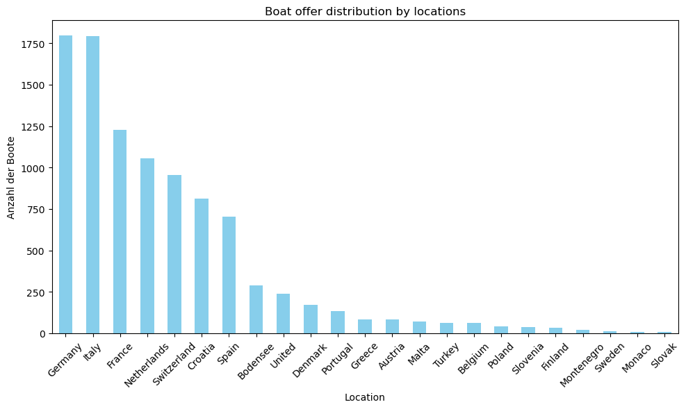

```python
# It can be seen that lot's of countries are in the data frame which holds less then 8 bot sail offers.
# These are not relevant for our purpose and will be removed.

# To clean the data we remove all locations values which are less then 8 in the distribution plot.

locations_to_keep = location_distribution[location_distribution >= 8].index

# Filter data frame to remain the important locations.
boat_data_cleaned_countries_splitted_filtered = boat_data_cleaned_countries_splitted.copy()
boat_data_cleaned_countries_splitted_filtered = boat_data_cleaned_countries_splitted[boat_data_cleaned_countries_splitted['Location'].isin(locations_to_keep)]

# Bootverteilung nach Locations zählen nach dem Filtern
location_distribution_filtered = boat_data_cleaned_countries_splitted_filtered['Location'].value_counts()

# Bar Chart plotten nach dem Filtern

# Bootverteilung nach Locations zählen nach dem Filtern
location_distribution_filtered = boat_data_cleaned_countries_splitted_filtered['Location'].value_counts()

# Bar Chart plotten nach dem Filtern
plt.figure(figsize=(10, 6))
location_distribution_filtered.plot(kind='bar', color='skyblue')
plt.title('Boat offer distribution by locations')
plt.xlabel('Location')
plt.ylabel('Anzahl der Boote')
plt.xticks(rotation=45)
plt.tight_layout()
plt.show()
```

```python
boat_data_cleaned_countries_splitted_filtered.head(7)
```

|  | Boat Type | Manufacturer | Type | Year Built | Length | Width | Material | Location | Number of views last 7 days | Price (EUR) | Location Area |
| --- | --- | --- | --- | --- | --- | --- | --- | --- | --- | --- | --- |
| 0 | Motor Yacht | Rigiflex power boats | new boat from stock | 2017 | 4.00 | 1.90 | NaN | Switzerland | 226 | 3070.04 | » Lake Geneva » Vésenaz |
| 1 | Center console boat | Terhi power boats | new boat from stock | 2020 | 4.00 | 1.50 | Thermoplastic | Germany | 75 | 3490.00 | » Bönningstedt |
| 2 | Sport Boat | Marine power boats | new boat from stock | 0 | 3.69 | 1.42 | Aluminium | Switzerland | 124 | 3468.40 | » Lake of Zurich » Stäfa ZH |
| 3 | Sport Boat | Pioner power boats | new boat from stock | 2020 | 3.00 | 1.00 | NaN | Denmark | 64 | 3367.00 | » Svendborg |
| 4 | Fishing Boat | Linder power boats | new boat from stock | 2019 | 3.55 | 1.46 | Aluminium | Germany | 58 | 3399.00 | » Bayern » München |
| 5 | Sport Boat | Linder power boats | new boat from stock | 0 | 4.03 | 1.56 | Aluminium | Bodensee | 132 | 3358.00 | NaN |
| 6 | Catamaran | NaN | Used boat,Unleaded | 1999 | 6.20 | 2.38 | Aluminium | Switzerland | 474 | 3312.00 | » Neuenburgersee » Yvonand |

### Result of Data preparation

- Multiple namings for lake of constance are replaced by Bodensee
- A new feature is created out of the original location feature. The new location contains the country of boat sell and the additional Location Area contains further information regarding the place in the country.
- The boat prices are recalculated in €.
- The data is plotted by distribution of boats to sell in the different countries.

We now have a good representative where we can further build the analysis on where we can buy the most popular boat for the Bodensee at the best price. Our data frame contains numerical as well as categorical features which needs to be interpreted seperatly in the following anlysis part.

### Analyze, Model, and Visualize

Provide a clear connection between your business questions and how the data answers them

1) What are the three most offered boats in Germany and what specifications do these boats have? 2) What sells best at the Bodensee (lake of constance)? 3) Where are these boats cheapest to buy in Germany?

### 1. What are the three most offered engine boats in Germany and what specifications do these boats have?

```python
# Load in the prepared boat data.
boat_data_cleaned_countries_splitted = pd.read_csv('boat_data_cleaned_countries_splitted.csv', sep=',',encoding='utf-8')
boat_data_cleaned_countries_splitted.head(7)
```

|  | Boat Type | Manufacturer | Type | Year Built | Length | Width | Material | Location | Number of views last 7 days | Price (EUR) | Location Area |
| --- | --- | --- | --- | --- | --- | --- | --- | --- | --- | --- | --- |
| 0 | Motor Yacht | Rigiflex power boats | new boat from stock | 2017 | 4.00 | 1.90 | NaN | Switzerland | 226 | 3070.04 | » Lake Geneva » Vésenaz |
| 1 | Center console boat | Terhi power boats | new boat from stock | 2020 | 4.00 | 1.50 | Thermoplastic | Germany | 75 | 3490.00 | » Bönningstedt |
| 2 | Sport Boat | Marine power boats | new boat from stock | 0 | 3.69 | 1.42 | Aluminium | Switzerland | 124 | 3468.40 | » Lake of Zurich » Stäfa ZH |
| 3 | Sport Boat | Pioner power boats | new boat from stock | 2020 | 3.00 | 1.00 | NaN | Denmark | 64 | 3367.00 | » Svendborg |
| 4 | Fishing Boat | Linder power boats | new boat from stock | 2019 | 3.55 | 1.46 | Aluminium | Germany | 58 | 3399.00 | » Bayern » München |
| 5 | Sport Boat | Linder power boats | new boat from stock | 0 | 4.03 | 1.56 | Aluminium | Bodensee | 132 | 3358.00 | NaN |
| 6 | Catamaran | NaN | Used boat,Unleaded | 1999 | 6.20 | 2.38 | Aluminium | Switzerland | 474 | 3312.00 | » Neuenburgersee » Yvonand |

```python
# How many categories of boats are in the data set?
unique_boat_type  = boat_data_cleaned_countries_splitted['Boat Type'].unique().tolist()
print('There are', len(unique_boat_type), 'boat types in the dataset')


#What are the tree most popular type of boats in Germany?
#Most offered boats for sale in Germany
boats_germany = boat_data_cleaned_countries_splitted[boat_data_cleaned_countries_splitted['Location'].str.contains('Germany', na=False)]
number_boat_types_germany = boats_germany['Boat Type'].value_counts().head(3)
print('The larghest number of boats for sale in Germany are\n', number_boat_types_germany)

#Most viewed boats in Germany by potential customeres
views_boats_germany = boats_germany.groupby('Boat Type')['Number of views last 7 days'].sum().sort_values(ascending=False).head(3)
print('\nMost viewed boats in Germany by potential customeres are', views_boats_germany)
```

```
There are 126 boat types in the dataset
The larghest number of boats for sale in Germany are
 Motor Yacht    412
Sport Boat     357
Cabin Boat     246
Name: Boat Type, dtype: int64

Most viewed boats in Germany by potential customeres are Boat Type
Motor Yacht    59202
Sport Boat     48970
Cabin Boat     40577
Name: Number of views last 7 days, dtype: int64
```

```
The average year build for Motor Yacht in Germany is: 2003.3615160349855
The average year build for Sport Boats in Germany is: 2013.9160839160838
The average year build for Cabin Boat in Germany is: 2004.4354838709678
Most favoured manufacturer of Motor Yachts in Germany: Jeanneau power boats
Most favoured manufacturer of Sport Boats in Germany: Sea Ray power boats
Most favoured manufacturer of Cabin Boats in Germany: Quicksilver power boats
```

[figure not shown]

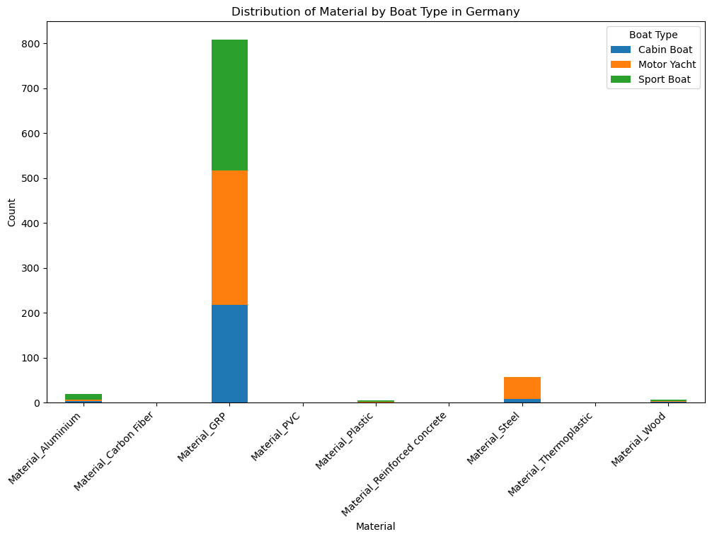

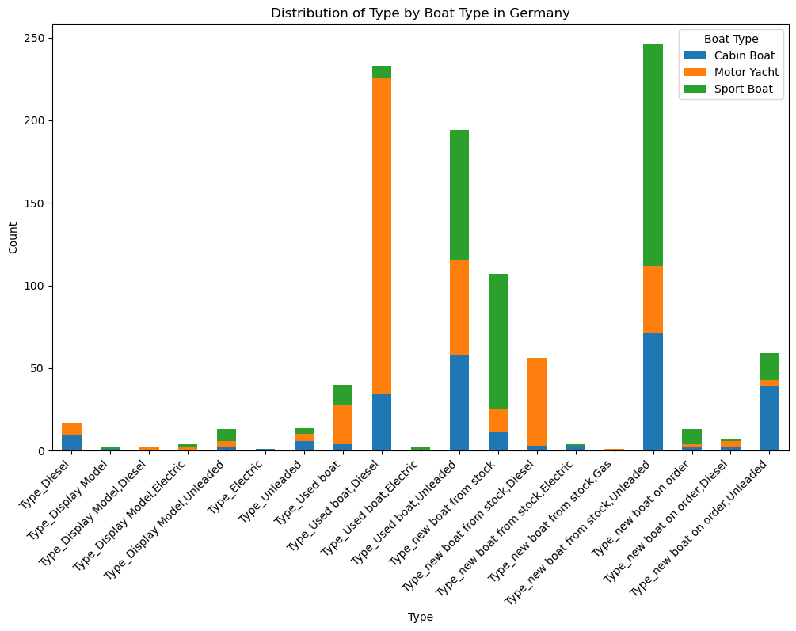

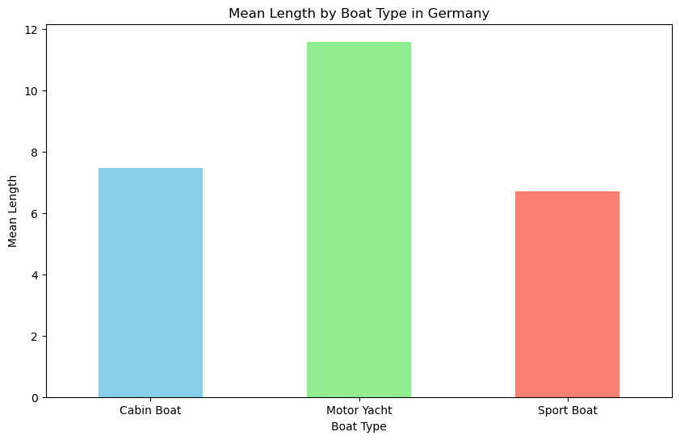

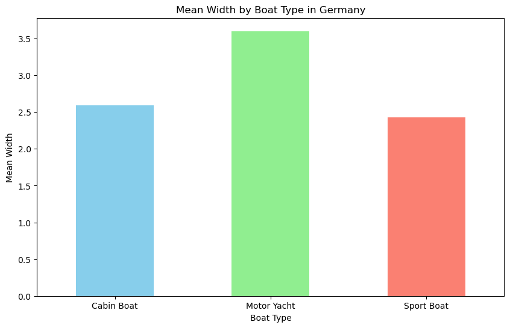

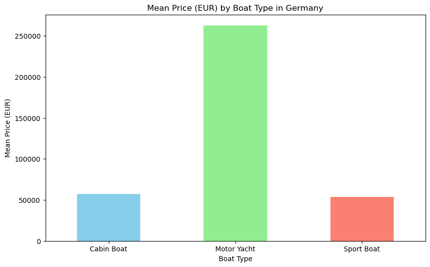

```python
# Filter boats by boat type
def filter_boat(df, BoatType):
    return df[df['Boat Type'] == BoatType]

# Clean the years where the boats are build, since in there are 0 or nan values which falsifies the average build year.
def clean_year_built_data(df):
    df_cleaned = df.dropna(subset=['Year Built'])  # Entfernt NaN-Werte
    df_cleaned = df_cleaned[df_cleaned['Year Built'] != 0]  # Entfernt 0-Wert
    return df_cleaned

#Plot the average year of build for the top three boats by category in Germany.
filtered_boats_germany_cleaned = clean_year_built_data(filter_boat(boats_germany, "Motor Yacht"))
average_year_built = filtered_boats_germany_cleaned['Year Built'].mean()
print(f"The average year build for Motor Yacht in Germany is: {average_year_built}")

filtered_boats_germany_cleaned = clean_year_built_data(filter_boat(boats_germany,'Sport Boat'))
average_year_built = filtered_boats_germany_cleaned['Year Built'].mean()
print(f"The average year build for Sport Boats in Germany is: {average_year_built}")

filtered_boats_germany_cleaned = clean_year_built_data(filter_boat(boats_germany, 'Cabin Boat'))
average_year_built = filtered_boats_germany_cleaned['Year Built'].mean()
print(f"The average year build for Cabin Boat in Germany is: {average_year_built}")


# Find the most popular manufacturer for boats of type "Motor Yacht" in Germany.
motor_yacht_germany = filter_boat(boats_germany, 'Motor Yacht')
top_manufacturer_germany = motor_yacht_germany['Manufacturer'].value_counts().idxmax()
print(f"Most favoured manufacturer of Motor Yachts in Germany: {top_manufacturer_germany}")

# Find the most popular manufacturer for boats of type "Sport Boats" in Germany.
sport_boats_germany = filter_boat(boats_germany, 'Sport Boat')
top_manufacturer_germany = sport_boats_germany['Manufacturer'].value_counts().idxmax()
print(f"Most favoured manufacturer of Sport Boats in Germany: {top_manufacturer_germany}")

# Find the most popular manufacturer for boats of type "Cabin Boats" in Germany.
cabin_boat_germany = filter_boat(boats_germany, 'Cabin Boat')
top_manufacturer_germany = cabin_boat_germany['Manufacturer'].value_counts().idxmax()
print(f"Most favoured manufacturer of Cabin Boats in Germany: {top_manufacturer_germany}")

# Heandling of categorical features for further analyis. A one-hot encoding is used.
# One Hot encoding for the columns "'Manufacturer', 'Material', 'Type'" for further analysis
boats_germany_one_hot = pd.get_dummies(boats_germany, columns=['Manufacturer', 'Material', 'Type'])

# Reduce data set to the three most poular boat types "Motor Yacht", "Sport Boat" and "Cabin Boat" in Germany
# and create plots for numerical and categorical features.
filtered_boats_germany = boats_germany_one_hot[boats_germany_one_hot['Boat Type'].isin(['Motor Yacht', 'Sport Boat', 'Cabin Boat'])]

# Bar Plots to create for the numerical and categorical features to get an overview
# about the most popular boat specifications for "Motor Yacht", "Sport Boat" and "Cabin Boat".
categorical_columns = ['Manufacturer', 'Material', 'Type']
numeric_columns = ['Length', 'Width', 'Price (EUR)']

# Bar Plots for distribution of Manufacturer, Material and Type for the three boat categories
for column in categorical_columns:
    plt.figure(figsize=(40, 6))
    column_data = filtered_boats_germany.filter(like=column)
    column_data_grouped = column_data.groupby(filtered_boats_germany['Boat Type']).sum()
    column_data_grouped.T.plot(kind='bar', stacked=True, figsize=(12, 7))
    plt.title(f'Distribution of {column} by Boat Type in Germany')
    plt.ylabel('Count')
    plt.xlabel(column)
    plt.xticks(rotation=45, ha='right')
    plt.legend(title='Boat Type')
    plt.show()

# Bar Plots for distribution of Year Built, Length and Width for the three boat categories
for column in numeric_columns:
    plt.figure(figsize=(10, 6))
    filtered_boats_germany.groupby('Boat Type')[column].mean().plot(kind='bar', color=['skyblue', 'lightgreen', 'salmon'])
    plt.title(f'Mean {column} by Boat Type in Germany')
    plt.ylabel(f'Mean {column}')
    plt.xlabel('Boat Type')
    plt.xticks(rotation=0)
    plt.show()
```

The most offered boat types in Germany by engine boats are Motor Yachts, Sport Boats and Cabin Boats. The same result appeares for the most viewed boats in the last 7 days in Germany. Therefore it can be stated that, the intereset in Germany is largest for these types of boats.

A Motor Yacht has the average specifications:

- ~3.5 m width
- ~11.5 m long
- Used diesel engine boat
- is build out of plastic based GRP material
- build by Jeanneau power Boats
- price ~250k€
- build 2003

A Sport Boat has the average specifications:

### 2. What sells best at Bodensee (lake of constance)?

```python
# How many categories of boats are in the data set?
unique_boat_type  = boat_data_cleaned_countries_splitted['Boat Type'].unique().tolist()
print('There are', len(unique_boat_type), 'boat types in the dataset')


#What are the tree most popular type of boats at the Bodensee?
#Most offered boats for sale at the Bodensee
boats_Bodensee = boat_data_cleaned_countries_splitted[boat_data_cleaned_countries_splitted['Location'].str.contains('Bodensee', na=False)]
number_boat_types_Bodensee = boats_Bodensee['Boat Type'].value_counts().head(3)
print('The larghest number of boats for sale at the Bodensee are\n', number_boat_types_Bodensee)

#Most viewed boats at the Bodensee by potential customeres
views_boats_Bodensee = boats_Bodensee.groupby('Boat Type')['Number of views last 7 days'].sum().sort_values(ascending=False).head(3)
print('\nThe Most viewed boats at the Bodensee are', views_boats_Bodensee)
```

```
There are 126 boat types in the dataset
The larghest number of boats for sale at the Bodensee are
 Sport Boat    96
Cabin Boat    39
Bowrider      34
Name: Boat Type, dtype: int64

The Most viewed boats at the Bodensee are Boat Type
Sport Boat     26055
Cabin Boat     12376
Motor Yacht    11236
Name: Number of views last 7 days, dtype: int64
```

The people who are thinking about buying a boat at the Bodensee (lake of constance) are most interested in a Sport Boat since there are the most views on advertisment for boat sales in the last 7 days. Fun fact is that at the same time this boat type are also available for sale most often. From my private experience of boat driving at the Bodensee (lake of constance) I can confirm that sport boats are the most popular boat types besides sailing boats at the Bodensse (lake of constance).

### 3. Where are the cheapest places to buy these boats in Germany?

```python
# Convert the price column into numerical values
sport_boats_germany['Price (EUR)'] = pd.to_numeric(sport_boats_germany['Price (EUR)'], errors='coerce')

# Arrange by price and choose the cheapes three entries.
cheapest_sport_boats = sport_boats_germany.sort_values(by='Price (EUR)').head(3)

# Plot results
print(cheapest_sport_boats[['Location Area', 'Price (EUR)']])
```

```
                                          Location Area  Price (EUR)
23    Â» BOOTSSERVICE ENK IN TREIS KARDEN, BOOTSSERV...       3900.0
22    Â» Nordrhein-Westfalen Â» WSC Hopp / MÃ¶ncheng...       3930.0
9885                    Â» Nordrhein-Westfalen Â» Wesel       4499.0
```

The most popular engine boats for the Bodensee can be bought at the lowest price in Rheinland-Pfalz and Nordrhein-Westfalen. Important to state is that there are spcial regulations regarding emissions and grey water for boats at the Bodensee (lake of constance). This can lead to further investments to get a boat licensed for the lake of constance. This furhter costs could not taken into account in this data set because there are no such information in the data set about the boats.